# R Notebook

对胡伟老师的实验进行可视化尝试，使用 ggplot2 包进行绘图，colorspace 包进行颜色选择。

### 1. 数据结构的实现：

考虑 ggplot2 需要数据框作为数据数据结构，同时选择 geom_tile 作为绘图函数，涉及到的 aes 包括 x，y，fill，因而设计的数据框结构如下：

| x | y | fill |
| --- | --- | --- |
| 1 | 1 | #000000 |
| 1 | 2 | #000001 |

其中，x，y 分别表示横纵坐标，fill 为 HCL 色值。 同时，为了便于程序随后的修改与扩展性，因而在本数据框加入数据分析的数据源，包括对不同单词出现频率，以及使用条件判断语句决定是否需要混色的factor。使用 wide-table 的形式表现，因此数据框结构如下：

| x | y | heed | hid | hood | head | mix | fill |
| --- | --- | --- | --- | --- | --- | --- | --- |
| 1 | 2 | 5 | 3 | 2 | 0 | 1 | #000000 |

### 2. 混色的实现：

由于为了使不同的数据通过颜色混合的形式表达出来，因此需要工具对色彩进行分析与混合，预期的方法是将特定的词频的颜色进行指定，随后根据映射关系将相应的色彩进行混合。查询 CRAN 后选择 colorspace 完成相应任务。

colorspace 是一个进行调色的 R package。CRAN 上的地址为：https://cran.r-project.org/web/packages/colorspace/ 。该工具包提供 vignettes ，地址为：https://cran.r-project.org/web/packages/colorspace/vignettes/hcl-colors.pdf 。本文的色彩实现主要通过该 vignettes 。

```r
library(colorspace)
library(tidyverse)
```

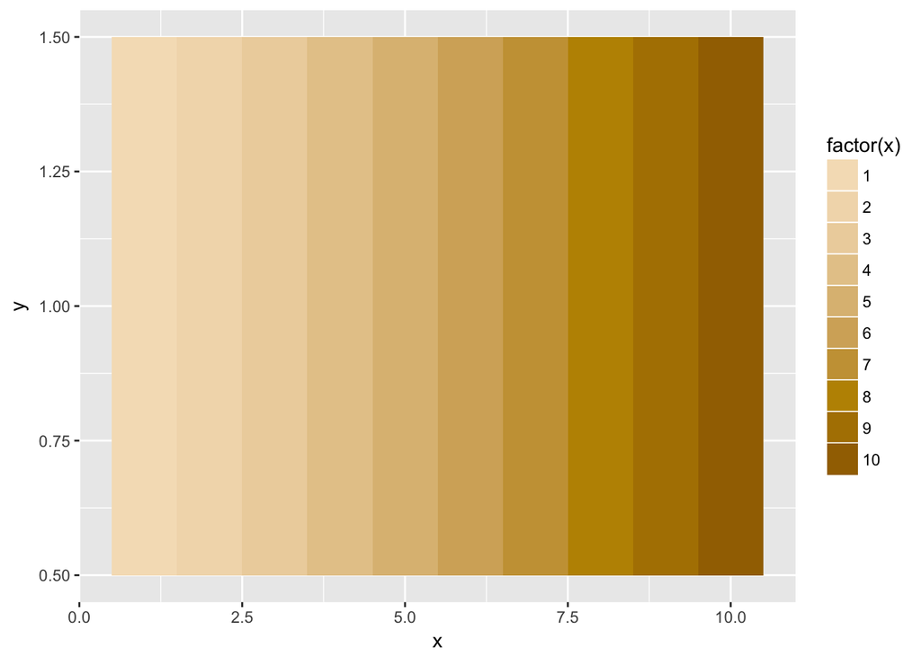

```r
color <- sequential_hcl(10, h = 60, c = c(100, 30), l = c(50, 90))
colortable <- data.frame(x = 1:10, y = 1, color = color) #构造绘图函数
names(color) <- factor(10:1) #构造色彩映射
ggplot(colortable, aes(x = x, y = y, fill = factor(x))) + geom_tile() + scale_fill_manual(values = color)
```

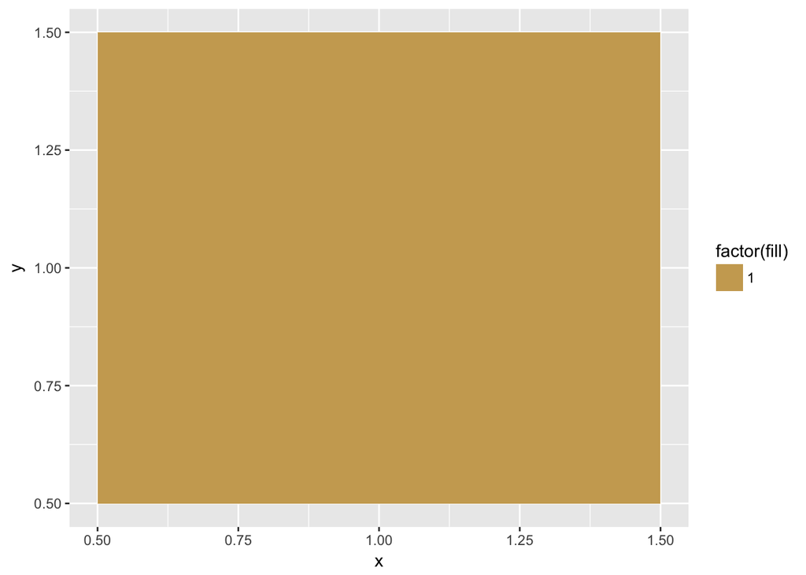

```r
mixcolorhcl <- function(first, second) {
  hex(mixcolor(alpha = 0.5,
               color1 = hex2RGB(first), color2 = hex2RGB(second)))
}

mixcolor <- mixcolorhcl(color[1], color[10])
names(mixcolor) <- "1"
mixtable <- data.frame(x = 1, y = 1, fill = 1)
ggplot(mixtable, aes(x = x, y = y, fill = factor(fill))) + geom_tile() + scale_fill_manual(values = mixcolor)
```

### 3. 表格的制作

```r
#配置分析环境
library(stringr)

#导入实验数据
en_nv <- read.csv("sub-data/English/nv.csv", header = T)
en_ihiy <- read.csv("sub-data/English/ihiy.csv", header = T)

#对数据进行初步筛选与整理
en_nv <- select(en_nv, answer1.Block., sound111, sound112)
en_ihiy <- select(en_ihiy, answer1.SubTrial.,answer2.SubTrial.,starts_with("sound"))

names(en_nv)[1] <- "answer"
names(en_ihiy)[1] <- "answer"
names(en_ihiy)[2] <- "rate"

#制作实验1的表格
en_nv <- unite(en_nv, sound, sound111, sound112)
en_ihiy <- unite(en_ihiy, col = sound, sound111, sound112, sound113, sound114, sound115, sound121, sound122, sound123, sound124, sound125)

#清除缺失值
en_nv <- na.omit(en_nv)
en_ihiy <- na.omit(en_ihiy)

#对数据中的文件路径含义进行修改

#将实验1的文件路径改为对应单词，并确认是否匹配
en_nv$sound <- str_extract(en_nv$sound, pattern = "(w|h).*d")
en_nv <- mutate(en_nv, match = sound == answer)
table(en_nv$match, en_nv$sound)
```

```
##
##         had hawed hayed head heard heed hid hod hoed hood hud whod
##   FALSE  15    15    15   11     0    5  15  16   16   16  16   20
##   TRUE    4     4     2    8    20   14   5   4    3    4   4    0
```

```r
#复杂频数表
# tidyr实现
en_nv %>%
  group_by(sound, match, answer) %>%
  tally() %>%
  spread(key = answer, value = n) %>%
  knitr::kable()
```

| sound | match | had | hawed | hayed | head | heard | heed | hid | hod | hoed | hood | hud | whod |
| --- | --- | --- | --- | --- | --- | --- | --- | --- | --- | --- | --- | --- | --- |
| had | FALSE | NA | 1 | 1 | 7 | NA | 2 | NA | 1 | 1 | 1 | 1 | NA |
| had | TRUE | 4 | NA | NA | NA | NA | NA | NA | NA | NA | NA | NA | NA |
| hawed | FALSE | NA | NA | NA | 1 | NA | NA | NA | 2 | 5 | 7 | NA | NA |
| hawed | TRUE | NA | 4 | NA | NA | NA | NA | NA | NA | NA | NA | NA | NA |
| hayed | FALSE | 1 | NA | NA | 6 | NA | 5 | 2 | NA | 1 | NA | NA | NA |
| hayed | TRUE | NA | NA | 2 | NA | NA | NA | NA | NA | NA | NA | NA | NA |
| head | FALSE | 10 | NA | NA | NA | NA | NA | NA | 1 | NA | NA | NA | NA |
| head | TRUE | NA | NA | NA | 8 | NA | NA | NA | NA | NA | NA | NA | NA |
| heard | TRUE | NA | NA | NA | NA | 20 | NA | NA | NA | NA | NA | NA | NA |
| heed | FALSE | NA | NA | NA | 1 | NA | NA | 4 | NA | NA | NA | NA | NA |
| heed | TRUE | NA | NA | NA | NA | NA | 14 | NA | NA | NA | NA | NA | NA |
| hid | FALSE | NA | NA | 2 | 3 | NA | 5 | NA | NA | 4 | NA | 1 | NA |
| hid | TRUE | NA | NA | NA | NA | NA | NA | 5 | NA | NA | NA | NA | NA |
| hod | FALSE | NA | 3 | NA | NA | 5 | NA | NA | NA | 2 | 4 | 2 | NA |
| hod | TRUE | NA | NA | NA | NA | NA | NA | NA | 4 | NA | NA | NA | NA |
| hoed | FALSE | NA | 2 | NA | NA | NA | NA | NA | 2 | NA | 6 | 3 | 3 |
| hoed | TRUE | NA | NA | NA | NA | NA | NA | NA | NA | 3 | NA | NA | NA |
| hood | FALSE | NA | NA | NA | NA | NA | NA | NA | 1 | NA | NA | 14 | 1 |
| hood | TRUE | NA | NA | NA | NA | NA | NA | NA | NA | NA | 4 | NA | NA |
| hud | FALSE | 4 | 4 | NA | 2 | 5 | NA | NA | NA | NA | 1 | NA | NA |
| hud | TRUE | NA | NA | NA | NA | NA | NA | NA | NA | NA | NA | 4 | NA |
| whod | FALSE | NA | NA | NA | NA | NA | NA | NA | NA | 1 | 7 | 12 | NA |

```r
# ftable实现
ftable(en_nv, row.vars = c(1,3), col.vars = 2)
```

```
##              sound had hawed hayed head heard heed hid hod hoed hood hud whod
## answer match
## had    FALSE         0     0     1   10     0    0   0   0    0    0   4    0
##        TRUE          4     0     0    0     0    0   0   0    0    0   0    0
## hawed  FALSE         1     0     0    0     0    0   0   3    2    0   4    0
##        TRUE          0     4     0    0     0    0   0   0    0    0   0    0
## hayed  FALSE         1     0     0    0     0    0   2   0    0    0   0    0
##        TRUE          0     0     2    0     0    0   0   0    0    0   0    0
## head   FALSE         7     1     6    0     0    1   3   0    0    0   2    0
##        TRUE          0     0     0    8     0    0   0   0    0    0   0    0
## heard  FALSE         0     0     0    0     0    0   0   5    0    0   5    0
##        TRUE          0     0     0    0    20    0   0   0    0    0   0    0
## heed   FALSE         2     0     5    0     0    0   5   0    0    0   0    0
##        TRUE          0     0     0    0     0   14   0   0    0    0   0    0
## hid    FALSE         0     0     2    0     0    4   0   0    0    0   0    0
##        TRUE          0     0     0    0     0    0   5   0    0    0   0    0
## hod    FALSE         1     2     0    1     0    0   0   0    2    1   0    0
##        TRUE          0     0     0    0     0    0   0   4    0    0   0    0
## hoed   FALSE         1     5     1    0     0    0   4   2    0    0   0    1
##        TRUE          0     0     0    0     0    0   0   0    3    0   0    0
## hood   FALSE         1     7     0    0     0    0   0   4    6    0   1    7
##        TRUE          0     0     0    0     0    0   0   0    0    4   0    0
## hud    FALSE         1     0     0    0     0    0   1   2    3   14   0   12
##        TRUE          0     0     0    0     0    0   0   0    0    0   4    0
## whod   FALSE         0     0     0    0     0    0   0   0    3    1   0    0
##        TRUE          0     0     0    0     0    0   0   0    0    0   0    0
```

```r
#将实验2的文件路径改为定位坐标
en_ihiy$sound <- str_extract(en_ihiy$sound, pattern = "F1_..-F2_..")
en_ihiy <- separate(en_ihiy, col = sound, into = c("X","Y"), sep = "-")
en_ihiy$X <- as.numeric(str_replace(en_ihiy$X, pattern = "F1_", replacement = ""))
en_ihiy$Y <- as.numeric(str_replace(en_ihiy$Y, pattern = "F2_", replacement = ""))

#对实验2中出现的单词数进行计数
summary(en_ihiy$answer)
```

```
##   had hawed hayed  head heard  heed   hid   hod  hoed  hood   hud  whod
##   185   145   249   504   381   370   398   187   213   162    80    55
```